# Practicial Machine Learning Project

Arnout van der Meijden

8/13/2020

## Machine learning assignment

### Synopsis

For this assignment we use the Weight Lifting Exercises Dataset (More info about the data is available at http://web.archive.org/web/20161224072740/http:/groupware.les.inf.puc-rio.br/har. This research was performed by: Velloso, E.; Bulling, A.; Gellersen, H.; Ugulino, W.; Fuks, H. Qualitative Activity Recognition of Weight Lifting Exercises. Proceedings of 4th International Conference in Cooperation with SIGCHI (Augmented Human ’13) . Stuttgart, Germany: ACM SIGCHI, 2013.

In this research six young health participants were asked to perform one set of 10 repetitions of the Unilateral Dumbbell Biceps Curl in five different fashions: exactly according to the specification (Class A), throwing the elbows to the front (Class B), lifting the dumbbell only halfway (Class C), lowering the dumbbell only halfway (Class D) and throwing the hips to the front (Class E). In this project, we will use the data from accelerometers on the belt, forearm, arm, and dumbell of 6 participants.

The goal of this project is to predict the manner in which they did the exercise provided in the testset.

Conclusion By reducing the number of variables we could a model using cross validation and bagging that has an accuraracy of about 98% on the trainingset.

### Data

First load the data

```r
training <- read.csv2("pml-training.csv", sep=",",na.strings = c("NA","NaN","","#DIV/0!"))
testing <- read.csv2("pml-testing.csv", sep="," ,na.strings = c("NA","NaN","","#DIV/0!"))
```

The training set consists of 19622 observations of 160 variables. The logical next step is to reduce the number of variables. Not being an expert on weightlifting or data from accelerometers I have no obvious candidates so I will just follow the ‘normal’ prodedure and that is removing variables which have more than 50% of NA’s. Imputting data if more than 50% is not available will probably lead to a algorithm which will not perform well on the testset or other data.

```r
training2 <- training[ , colSums(is.na(training)) <nrow(training)*0.5]
```

It seems we got a lot of variables with more than 50% of NA’s. We only have 60 variables left. Let’s do some exploratory analysis using graphs on these diminished set.

[figure not shown]

```r
library(ggplot2)
ggplot(data=training2b, aes(gyros_arm_x,magnet_arm_x))+
  geom_point(aes(color=classe))
```

I couldn’t find any meaningfull plot. The only conclusion for me was that I needed to trim down the number of predictors. Next step in this reduction phase is to remove any variables which have no variance and remove that. After that I want to find the predictors which are highly correlated.

To be able to calculate the variance and correlation factor I first need to make the factor variables numeric.

```r
training2f <- training2b[,-53] %>%
  select_if(is.factor)

library(tidyverse)
training2nf <- training2b %>%
  select_if(negate(is.factor))

## Convert all columns to numeric of a dataset with only factors
training2fn <- lapply(training2f, function(x) as.numeric(levels(x))[x])

## Combine these datasets to get a dataset with all numeric values (except of course classe)
training3 <- cbind(training2nf, training2fn, training2b$classe)

colnames(training3)[53] <- "classe"
```

Let’s see if we have some variables with no variance

```r
library(caret)
nearZeroVar(training3[,-53], saveMetrics = TRUE)
```

```
##                      freqRatio percentUnique zeroVar   nzv
## total_accel_belt      1.063160     0.1477933   FALSE FALSE
## accel_belt_x          1.055412     0.8357966   FALSE FALSE
## accel_belt_y          1.113725     0.7287738   FALSE FALSE
## accel_belt_z          1.078767     1.5237998   FALSE FALSE
## magnet_belt_x         1.090141     1.6664968   FALSE FALSE
## magnet_belt_y         1.099688     1.5187035   FALSE FALSE
## magnet_belt_z         1.006369     2.3290184   FALSE FALSE
## total_accel_arm       1.024526     0.3363572   FALSE FALSE
## accel_arm_x           1.017341     3.9598410   FALSE FALSE
## accel_arm_y           1.140187     2.7367241   FALSE FALSE
## accel_arm_z           1.128000     4.0362858   FALSE FALSE
## magnet_arm_x          1.000000     6.8239731   FALSE FALSE
## magnet_arm_y          1.056818     4.4439914   FALSE FALSE
## magnet_arm_z          1.036364     6.4468454   FALSE FALSE
## total_accel_dumbbell  1.072634     0.2191418   FALSE FALSE
## accel_dumbbell_x      1.018018     2.1659362   FALSE FALSE
## accel_dumbbell_y      1.053061     2.3748853   FALSE FALSE
## accel_dumbbell_z      1.133333     2.0894914   FALSE FALSE
## magnet_dumbbell_x     1.098266     5.7486495   FALSE FALSE
## magnet_dumbbell_y     1.197740     4.3012945   FALSE FALSE
## total_accel_forearm   1.128928     0.3567424   FALSE FALSE
## accel_forearm_x       1.126437     4.0464784   FALSE FALSE
## accel_forearm_y       1.059406     5.1116094   FALSE FALSE
## accel_forearm_z       1.006250     2.9558659   FALSE FALSE
## magnet_forearm_x      1.012346     7.7667924   FALSE FALSE
## roll_belt             1.101904     6.7781062   FALSE FALSE
## pitch_belt            1.036082     9.3772296   FALSE FALSE
## yaw_belt              1.058480     9.9734991   FALSE FALSE
## gyros_belt_x          1.058651     0.7134849   FALSE FALSE
## gyros_belt_y          1.144000     0.3516461   FALSE FALSE
## gyros_belt_z          1.066214     0.8612782   FALSE FALSE
## roll_arm             52.338462    13.5256345   FALSE FALSE
## pitch_arm            87.256410    15.7323412   FALSE FALSE
## yaw_arm              33.029126    14.6570176   FALSE FALSE
## gyros_arm_x           1.015504     3.2769341   FALSE FALSE
## gyros_arm_y           1.454369     1.9162165   FALSE FALSE
## gyros_arm_z           1.110687     1.2638875   FALSE FALSE
## roll_dumbbell         1.022388    84.2065029   FALSE FALSE
## pitch_dumbbell        2.277372    81.7449801   FALSE FALSE
## yaw_dumbbell          1.132231    83.4828254   FALSE FALSE
## gyros_dumbbell_x      1.003268     1.2282132   FALSE FALSE
## gyros_dumbbell_y      1.264957     1.4167771   FALSE FALSE
## gyros_dumbbell_z      1.060100     1.0498420   FALSE FALSE
## magnet_dumbbell_z     1.020833     3.4451126   FALSE FALSE
## roll_forearm         11.589286    11.0895933   FALSE FALSE
## pitch_forearm        65.983051    14.8557741   FALSE FALSE
## yaw_forearm          15.322835    10.1467740   FALSE FALSE
## gyros_forearm_x       1.059273     1.5187035   FALSE FALSE
## gyros_forearm_y       1.036554     3.7763735   FALSE FALSE
## gyros_forearm_z       1.122917     1.5645704   FALSE FALSE
## magnet_forearm_y      1.246914     9.5403119   FALSE FALSE
## magnet_forearm_z      1.000000     8.5771073   FALSE FALSE
```

No variables with zero or near zero variance so still the same amount of variables. Next find the predictors which are highly correlated.

```r
PCA <- abs(cor(training3[,-53]))
diag(PCA) <- 0 ## Diagnols always have 1 (because it always correlates with itself)
nearzerovariance <- which(PCA > 0.75, arr.ind=T) ## Get's 48 results
head(nearzerovariance) ## Let's look at the first results
```

```
##               row col
## accel_belt_y    3   1
## accel_belt_z    4   1
## accel_arm_y    10   1
## roll_belt      26   1
## yaw_belt       28   1
## magnet_belt_x   5   2
```

A lot of variables which are highly correlated (>0,75). So we only need one of these two correlated predictors. We will keep the variable which has the highest correlation with classe.

To know which predictor has the highest correlation with classe, let’s create a graph wich shows the correlation of these predictors with classe.

```r
training4 <- training3
training4$classe <- as.numeric(training4$classe)
```

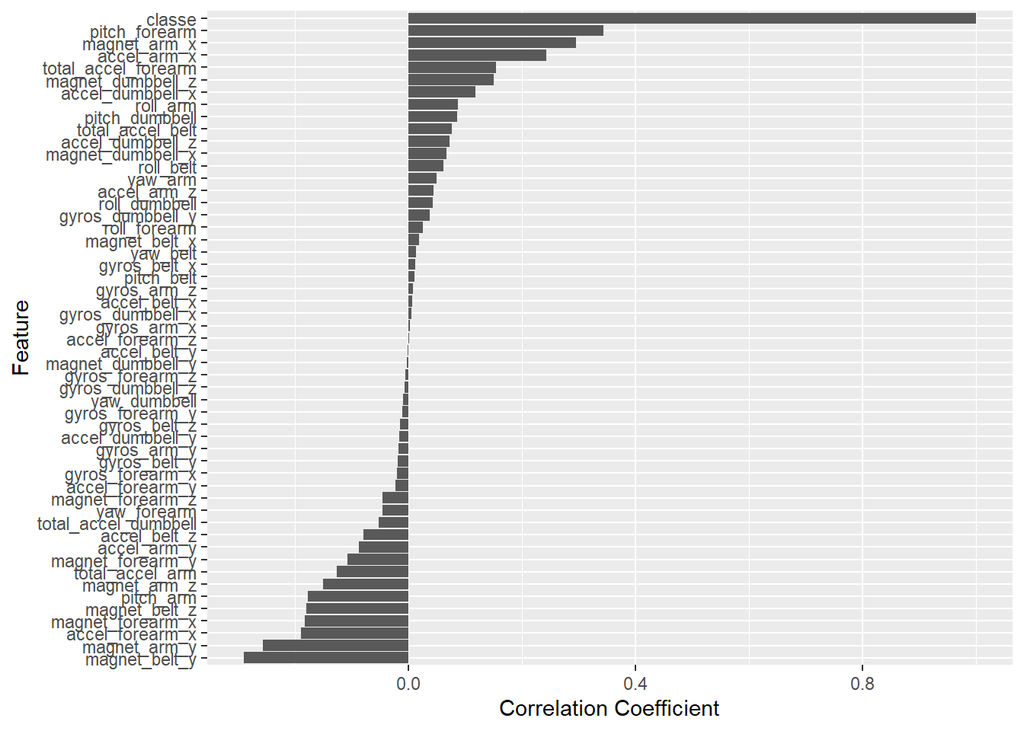

```r
Classe <- training4$classe
feature <- names(training4)

corrClasse <- data.frame(feature = feature, coef = rep(NA, length(feature)))
for (iFeature in 1:length(feature)){
  corrClasse$coef[iFeature] <- cor(training4[, iFeature], Classe)
}

# sort by correlation coefficient
corrClasseOrder <- corrClasse[order(corrClasse$coef, decreasing = FALSE), ]

## Make the plot
ggplot(corrClasseOrder, aes(x = factor(feature, levels = feature), y = coef)) +
  geom_bar(stat = "identity") +
  coord_flip() +
  xlab("Feature") +
  ylab("Correlation Coefficient")
```

Comparing which predictor has the highest correlation with Classe, we keep that one and remove the other predictor, 18 variabels are removed.

```r
training5 <- select(training4, -c(4, 26, 3, 10, 28, 2, 7, 13, 11, 17, 39, 40, 20, 23, 27, 35, 41, 50))
```

### Building models

Let’s see if we can make a nice decision tree

[figure not shown]

```r
training51 <- select(training5, -c(35))
training52 <- cbind(training51, training$classe)
colnames(training52)[35] <- "classe"

library(caret)
modfit1c <-  train(classe ~., data = training52, method="rpart")
rattle::fancyRpartPlot(modfit1c$finalModel)
```

```r
print(modfit1c$results)
```

```
##           cp  Accuracy     Kappa AccuracySD    KappaSD
## 1 0.02047429 0.5426581 0.4138361 0.03702221 0.05201555
## 2 0.02079476 0.5391206 0.4087594 0.03531592 0.04973978
## 3 0.04226606 0.4440108 0.2709661 0.06842921 0.11376751
```

### Cross validation

So let’s try to improve the accuracy by using bagging with cross validation (as requested in the assignment). The basis idea behind cross validation is to divide the data in multiple sets. So I train the model using bagging (boostrap aggregating) which is also about taking the data and take resamples of the data, recalculate the prediction, repeat this a couple of times (in this case 10 times), take the average of the prediction. Metric is Accuracy because it is a classification problem. Why not use Kappa? Kappa is a more usefull measure to use on problems that have an imbalance in the classes. Which in this case we don’t have. RMSE and R^2 are default metrics used to evaluate algorithms on regession datasets but we have a classification dataset so we don’t use these measures. Area under ROC curve metrix are only suitable for binary classification problems (two classes). Later I will also use the logless metric and see if we get the same results.

```r
library(e1071)
library(ipred)
trCtrl <- trainControl(method = "cv", number = 10) ## k-fold Cross Validation
modfitbag1 <- train(classe ~., data = training52, method="treebag", trControl=trCtrl, metric="Accuracy")
print(modfitbag1$results)
```

```
##   parameter  Accuracy    Kappa AccuracySD     KappaSD
## 1      none 0.9849152 0.980915 0.00402063 0.005086552
```

### Out of sample error

The accuraracy of this model is about 98%, on the trainset of course. This means we could be overfitting but I expect the accurracy on the testset should be about 95%. Which means that this model will probably have 1 of the 20 predictions in the testset wrong. I haven’t split the trainingset to get a more accurate out of sample error. I can’t measure out of sample errors like RMSE because I don’t have predictions on the testset.

To do the predictions we first need to setup the testset to have the same transformations.

```r
## Remove all the variables with more than 50% in the trainingset.

testing2 <- testing[ , colSums(is.na(training)) <nrow(training)*0.5]
testing2b <-  select(testing2, -c(1,2,3,4,5,6,7))

testing2f <- testing2b[,-53] %>%
  select_if(is.factor)

testing2nf <- testing2b %>%
  select_if(negate(is.factor))

testing2fn <- lapply(testing2f, function(x) as.numeric(levels(x))[x])

## Combine these datasets to get a dataset with all numeric values
testing3 <- cbind(testing2nf, testing2fn)

testing3 <- testing2b

## Remove the same variables as the testste
testing5 <- select(testing3, -c(8,9,10,13,22,23,25,35,38,48,1,2,3,18,28,29,31,46))

testing6 <- testing5 %>%
  select_if(is.factor)

testing7 <- testing5  %>%
  select_if(negate(is.factor))

testing8 <- lapply(testing6, function(x) as.numeric(levels(x))[x])

testing9 <- cbind(testing8, testing7)

################## Now we can predict for the 20 observations

PredictClassTest <- predict(modfitbag1, testing9)

results <- data.frame("Participant"=testing$user_name, "Problem_id"=testing$problem_id,
                      "Classe"=PredictClassTest)
print(results)
```

```
##    Participant Problem_id Classe
## 1        pedro          1      B
## 2       jeremy          2      A
## 3       jeremy          3      B
## 4       adelmo          4      A
## 5       eurico          5      A
## 6       jeremy          6      E
## 7       jeremy          7      D
## 8       jeremy          8      B
## 9     carlitos          9      A
## 10     charles         10      A
## 11    carlitos         11      B
## 12      jeremy         12      C
## 13      eurico         13      B
## 14      jeremy         14      A
## 15      jeremy         15      E
## 16      eurico         16      E
## 17       pedro         17      A
## 18    carlitos         18      B
## 19       pedro         19      B
## 20      eurico         20      B
```

Other model which I made was based on the logloss metric. This metric punishes ‘wrong’ predictions.

```r
trCtrl <- trainControl(method = "cv", number = 10, classProbs=TRUE, summaryFunction=mnLogLoss) ## k-fold Cross Validation
modfitbag1ll <- train(classe ~., data = training52, method="treebag", trControl=trCtrl, metric="logLoss")
print(modfitbag1ll)
```

```
## Bagged CART
##
## 19622 samples
##    34 predictor
##     5 classes: 'A', 'B', 'C', 'D', 'E'
##
## No pre-processing
## Resampling: Cross-Validated (10 fold)
## Summary of sample sizes: 17660, 17660, 17660, 17660, 17659, 17660, ...
## Resampling results:
##
##   logLoss
##   0.1087905
```

This model gets the same results for the prediction on the testset.

```r
PredictClassTestll <- predict(modfitbag1ll, testing9)

resultsll <- data.frame("Participant"=testing$user_name, "Problem_id"=testing$problem_id,
                      "Classe"=PredictClassTestll)
print(resultsll)
```

```
##    Participant Problem_id Classe
## 1        pedro          1      B
## 2       jeremy          2      A
## 3       jeremy          3      B
## 4       adelmo          4      A
## 5       eurico          5      A
## 6       jeremy          6      E
## 7       jeremy          7      D
## 8       jeremy          8      B
## 9     carlitos          9      A
## 10     charles         10      A
## 11    carlitos         11      B
## 12      jeremy         12      C
## 13      eurico         13      B
## 14      jeremy         14      A
## 15      jeremy         15      E
## 16      eurico         16      E
## 17       pedro         17      A
## 18    carlitos         18      B
## 19       pedro         19      B
## 20      eurico         20      B
```